# Reproducible Research: Peer Assessment 1

## Introduction

The objective of this assignment is to analyse data generated by a personal activity monitoring device to answer identified questions and report on these in an R markdown document.

Sections of the report answering sub-questions of the assignment are highglighted in **bold** typeface.

The following global options have been used in the report

```r
knitr::opts_chunk$set(fig.width=12,
                      fig.height=8,
                      fig.path='figures/',
                      echo=TRUE,
                      warning=FALSE,
                      message=FALSE)

library(ggplot2)
library(dplyr)
options(scipen = 999)
```

## Loading and preprocessing the data

**Code needed to load the data and processing the data into a format suitable for analysis is as follows.**

```r
activity <- read.csv(file="activity.csv",
                     colClasses=c("steps"="integer", "date"="Date", "interval"="integer"))
```

## What is mean total number of steps taken per day?

Mean of the total number of steps per each day has been determined as follows.

Firstly, we need to **calculate the total number of steps taken per day**.

```r
steps_daily_total <-
        activity %>%
        group_by(date) %>%
        summarise (steps= sum(steps))
head(steps_daily_total)
```

```
## # A tibble: 6 x 2
##   date       steps
##   <date>     <int>
## 1 2012-10-01    NA
## 2 2012-10-02   126
## 3 2012-10-03 11352
## 4 2012-10-04 12116
## 5 2012-10-05 13294
## 6 2012-10-06 15420
```

Secondly, we **make a histogram of the total number of steps taken each day**

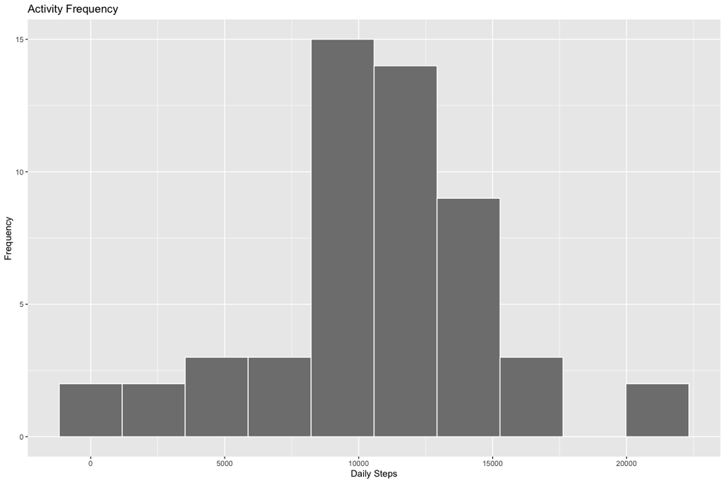

```r
ggplot(steps_daily_total, aes(x=steps)) +
        geom_histogram(bins=10, fill="grey50", color="white") +
        labs (x="Daily Steps", y="Frequency", title = "Activity Frequency")
```

Thirdly, we **calculate and report the mean and median of the total number of steps taken per day**

```r
mean_daily_steps <- round(mean(steps_daily_total$steps, na.rm=TRUE))
median_daily_steps <- round(median(steps_daily_total$steps, na.rm=TRUE))
```

- Mean : 10766
- Median : 10765

## What is the average daily activity pattern?

```r
steps_interval_avg <-
        activity %>%
        group_by(interval) %>%
        summarise (steps=mean(steps, na.rm=TRUE)) %>%
        ungroup() %>%
        arrange(interval)
head(steps_interval_avg)
```

```
## # A tibble: 6 x 2
##   interval  steps
##      <int>  <dbl>
## 1        0 1.72
## 2        5 0.340
## 3       10 0.132
## 4       15 0.151
## 5       20 0.0755
## 6       25 2.09
```

This data was then used to **Make a time series plot of the 5-minute interval and the average number of steps taken, averaged across all days**

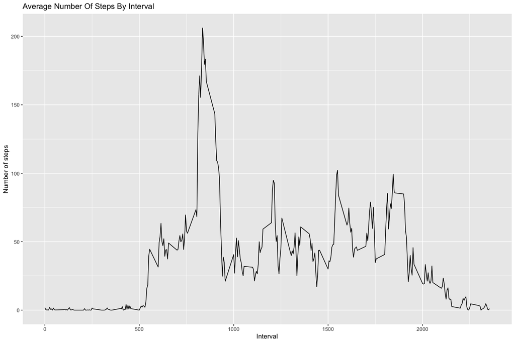

```r
ggplot(steps_interval_avg, aes(interval, steps)) +
        geom_line() +
        labs (x="Interval", y="Number of steps", title = "Average Number Of Steps By Interval")
```

The data was also used to answer the question: **“Which 5-minute interval that, on average, contains the maximum number of steps?”**

```r
peak_interval <- as.integer(steps_interval_avg [which.max(steps_interval_avg$steps),"interval"])

peak_steps <- as.integer(steps_interval_avg [which.max(steps_interval_avg$steps),"steps"])

peak_interval_time <- sprintf("%.02d:%.02d", peak_interval %/% 60, round(peak_interval %% 60))
```

## Imputing missing values

Firstly, we **calculate total number of missing values in the dataset (i.e. the total number of rows with NAs).**

```r
missing_values_rows <- sapply(activity, function(x) sum(is.na(x)))
missing_values_rows
```

```
##    steps     date interval
##     2304        0        0
```

We then need to **Devise a strategy for filling in all of the missing values in the dataset.** This strategy involves using the mean number of steps in 5 minutes interval across all days (from steps_interval_avg data frame).

Subsequently, we **use this strategy to create a new dataset that is equal to the original dataset but with the missing data filled in.**

```r
activity_imputed <- # order activity data in the same way as steps_interval_avg
        activity %>% arrange(date, interval)
activity_imputed$steps <- # fill in the missing numbers from steps_interval_avg
        coalesce(activity$steps,
                 rep(steps_interval_avg$steps,
                 times=length(activity$steps)/length(steps_interval_avg$steps)))
head(activity_imputed)
```

```
##       steps       date interval
## 1 1.7169811 2012-10-01        0
## 2 0.3396226 2012-10-01        5
## 3 0.1320755 2012-10-01       10
## 4 0.1509434 2012-10-01       15
## 5 0.0754717 2012-10-01       20
## 6 2.0943396 2012-10-01       25
```

```r
steps_imputed_daily_total <- # summarise the imputed activity data set
        activity_imputed %>% group_by(date) %>% summarise (steps= sum(steps))
head(steps_imputed_daily_total)
```

```
## # A tibble: 6 x 2
##   date        steps
##   <date>      <dbl>
## 1 2012-10-01 10766.
## 2 2012-10-02   126
## 3 2012-10-03 11352
## 4 2012-10-04 12116
## 5 2012-10-05 13294
## 6 2012-10-06 15420
```

Subsequently, we use this data to **make a histogram of the total number of steps taken each day**

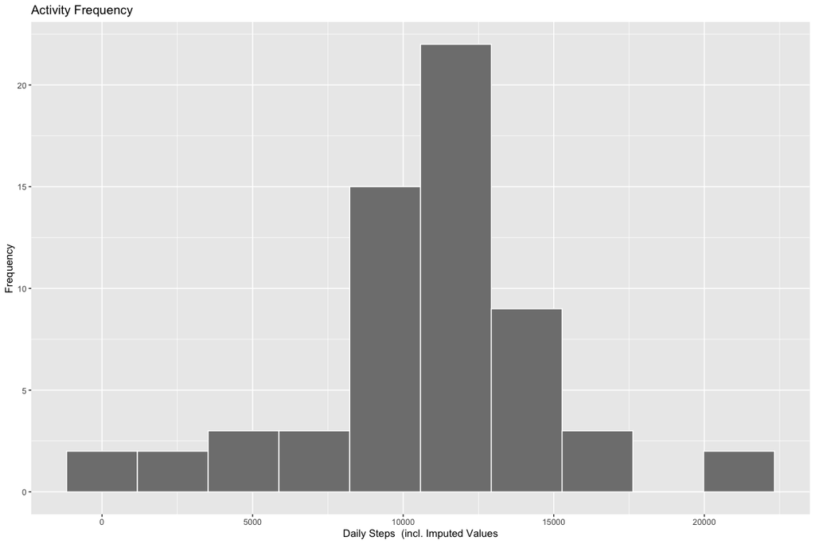

```r
ggplot(steps_imputed_daily_total, aes(x=steps)) +
        geom_histogram(bins=10, fill="grey50", color="white") +
        labs (x="Daily Steps  (incl. Imputed Values", y="Frequency", title = "Activity Frequency")
```

We also use this data to understand the impact of imputation on overall characteristics of the data set:

**Calculate and report the mean and median total number of steps taken per day.**

```r
mean_daily_steps_imputed <- round(mean(steps_imputed_daily_total$steps, na.rm=TRUE))
median_daily_steps_imputed <- round(median(steps_imputed_daily_total$steps, na.rm=TRUE))
```

```r
mean_daily_steps_imputed
```

```
## [1] 10766
```

```r
median_daily_steps_imputed
```

```
## [1] 10766
```

**Do these values differ from the estimates from the first part of the assignment?**

```r
mean_daily_steps_imputed - mean_daily_steps
```

```
## [1] 0
```

```r
median_daily_steps_imputed - median_daily_steps
```

```
## [1] 1
```

Analysis below shows **what is the impact of imputing missing data on the estimates of the total daily number of steps?**, by showing the magnitude of difference (steps_dif) between the number of steps in the original data set (steps_original) and number of steps in the data set with imputations (steps_imputed).

```r
steps_daily_total_dif <-
        steps_daily_total %>%               # copy the steps_daily_total data set
        mutate(steps_original0=steps) %>%   # create a copy of the steps column called steps_original0
        rename(steps_original=steps) %>%    # rename steps column to steps_original
        tidyr::replace_na(list(steps_original0=0)) %>% # replace NAs in steps_original0 with zeros
        mutate (steps_imputed = steps_imputed_daily_total$steps, # create a copy of the column steps_imputed
                steps_dif = steps_imputed-steps_original0) %>% #calculated difference between the two columns
        filter(steps_dif!=0) %>%             # filter out columns with zero difference
        select (-steps_original0)            # remove steps_original0
steps_daily_total_dif
```

```
## # A tibble: 8 x 4
##   date       steps_original steps_imputed steps_dif
##   <date>              <int>         <dbl>     <dbl>
## 1 2012-10-01             NA        10766.    10766.
## 2 2012-10-08             NA        10766.    10766.
## 3 2012-11-01             NA        10766.    10766.
## 4 2012-11-04             NA        10766.    10766.
## 5 2012-11-09             NA        10766.    10766.
## 6 2012-11-10             NA        10766.    10766.
## 7 2012-11-14             NA        10766.    10766.
## 8 2012-11-30             NA        10766.    10766.
```

## Are there differences in activity patterns between weekdays and weekends?

We use the activity data set to **create a new factor variable in the dataset with two levels – “weekday” and “weekend” indicating whether a given date is a weekday or weekend day.**

```r
activity_imputed$daytype <- factor(
        (weekdays(activity_imputed$date) %in% c("Saturday", "Sunday")),
        labels=c("Weekday", "Weekend"))
head(activity_imputed)
```

```
##       steps       date interval daytype
## 1 1.7169811 2012-10-01        0 Weekday
## 2 0.3396226 2012-10-01        5 Weekday
## 3 0.1320755 2012-10-01       10 Weekday
## 4 0.1509434 2012-10-01       15 Weekday
## 5 0.0754717 2012-10-01       20 Weekday
## 6 2.0943396 2012-10-01       25 Weekday
```

As a preparation for the next step, we then calculate average number of steps taken, averaged across all days, separate for weekday and weekend days.

```r
steps_imputed_interval_avg <-
        activity_imputed %>%
        group_by(daytype, interval) %>%
        summarise (steps= round(mean(steps)))
head(steps_imputed_interval_avg)
```

```
## # A tibble: 6 x 3
## # Groups:   daytype [1]
##   daytype interval steps
##   <fct>      <int> <dbl>
## 1 Weekday        0     2
## 2 Weekday        5     0
## 3 Weekday       10     0
## 4 Weekday       15     0
## 5 Weekday       20     0
## 6 Weekday       25     2
```

Subsequently we **make a panel plot comparing the average number of steps taken per 5-minute interval across weekdays and weekends**.

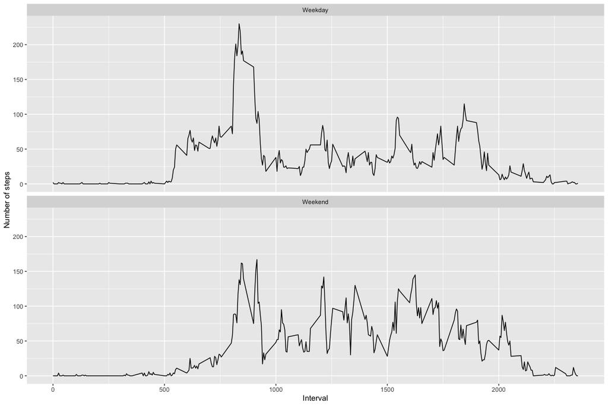

```r
ggplot(steps_imputed_interval_avg, aes(interval, steps)) + geom_line()  + facet_wrap(vars(daytype), nrow=2) + labs (x="Interval", y="Number of steps")
```